# PCIT-CoS-Waitlist RCT Paper 1: Child positivity (NICHD), Controlling for ASD

Nancy Briggs

05 JAN 2021

### Child positivity (NICHD) Adjusting for ASD

#### Descriptives

Raw Data

| group | time | n | mean | sd | median | min | max |
| --- | --- | --- | --- | --- | --- | --- | --- |
| 1 | NA | NA | NA | NA | NA | NA | NA |
| 1 | 1 | 22 | 11.159 | 2.688 | 11.50 | 7 | 16 |
| 1 | 2 | 18 | 11.111 | 2.494 | 11.00 | 7 | 16 |
| 1 | 3 | 12 | 13.250 | 2.864 | 13.50 | 7 | 17 |
| 2 | NA | NA | NA | NA | NA | NA | NA |
| 2 | 1 | 25 | 10.587 | 2.876 | 10.00 | 6 | 16 |
| 2 | 2 | 10 | 9.700 | 1.703 | 10.00 | 6 | 12 |
| 2 | 3 | 4 | 14.500 | 1.000 | 15.00 | 13 | 15 |
| 3 | NA | NA | NA | NA | NA | NA | NA |
| 3 | 1 | 22 | 10.814 | 2.939 | 10.00 | 6 | 17 |
| 3 | 2 | 17 | 9.941 | 2.512 | 10.00 | 6 | 16 |
| 3 | 3 | 0 | NaN | NA | NA | Inf | -Inf |
| 1 | NA | NA | NA | NA | NA | NA | NA |
| 1 | 1 | 6 | 10.667 | 3.983 | 10.00 | 6 | 18 |
| 1 | 2 | 3 | 10.333 | 4.041 | 8.00 | 8 | 15 |
| 1 | 3 | 4 | 9.750 | 1.708 | 9.50 | 8 | 12 |
| 2 | NA | NA | NA | NA | NA | NA | NA |
| 2 | 1 | 3 | 10.667 | 3.786 | 9.00 | 8 | 15 |
| 2 | 2 | 2 | 8.000 | 1.414 | 8.00 | 7 | 9 |
| 2 | 3 | 0 | NaN | NA | NA | Inf | -Inf |
| 3 | NA | NA | NA | NA | NA | NA | NA |
| 3 | 1 | 5 | 10.200 | 2.490 | 11.00 | 6 | 12 |
| 3 | 2 | 4 | 8.725 | 3.302 | 8.45 | 5 | 13 |
| 3 | 3 | 0 | NaN | NA | NA | Inf | -Inf |

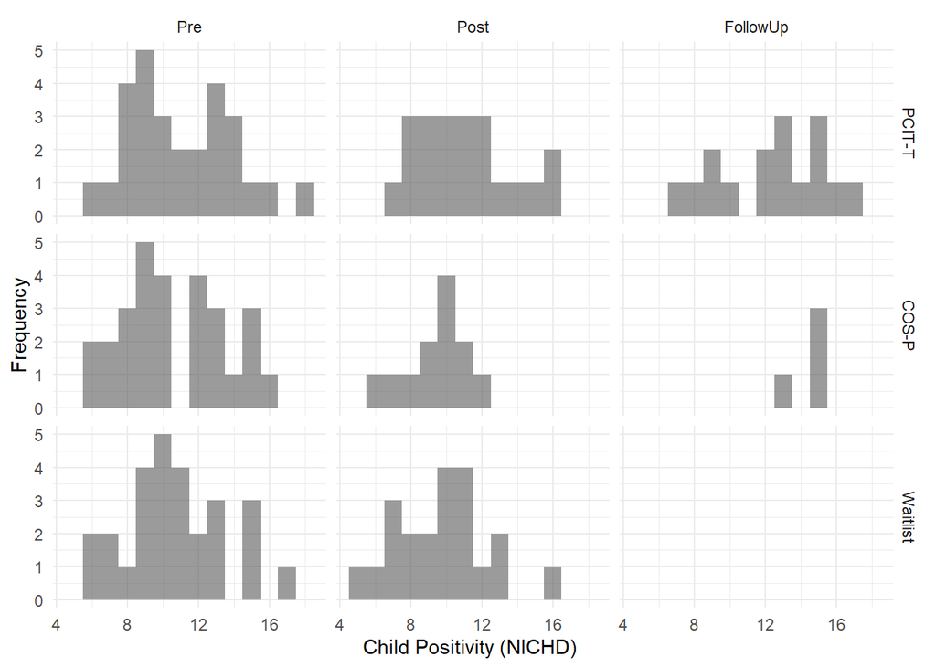

#### Model & Results

A linear mixed model with random effect for individual and fixed effects of group, time and the interaction was run. ASD status was then entered into the model as a main effect and then the 3-way interaction. Estimated marginal means were obtained, and contrasts specified to test Hypothesis 1 and Hypothesis 2.

```
## boundary (singular) fit: see help('isSingular')
## boundary (singular) fit: see help('isSingular')
```

```
## fixed-effect model matrix is rank deficient so dropping 1 column / coefficient
```

```
## boundary (singular) fit: see help('isSingular')
```

```
## fixed-effect model matrix is rank deficient so dropping 3 columns / coefficients
```

```
## boundary (singular) fit: see help('isSingular')
```

```
## refitting model(s) with ML (instead of REML)
```

[output not shown]

There is no evidence that ASD moderates the 2-way group*time interaction (the 3-way interaction p=0.733).

Model3, the model with Group*Time, adjusted by ASD will be the model I use for Estimated Means.

```r
summary(result3)
```

```
## Linear mixed model fit by REML. t-tests use Satterthwaite's method [
## lmerModLmerTest]
## Formula: outcome ~ asdcase + group * time + (1 | id)
##    Data: dat
##
## REML criterion at convergence: 741.5
##
## Scaled residuals:
##      Min       1Q   Median       3Q      Max
## -2.07964 -0.70027  0.03064  0.63094  2.87304
##
## Random effects:
##  Groups   Name        Variance Std.Dev.
##  id       (Intercept) 0.000    0.000
##  Residual             7.373    2.715
## Number of obs: 157, groups:  id, 86
##
## Fixed effects:
##              Estimate Std. Error       df t value Pr(>|t|)
## (Intercept)   11.2868     0.5280 148.0000  21.377   <2e-16 ***
## asdcase1      -1.0882     0.5797 148.0000  -1.877   0.0624 .
## group2        -0.5749     0.7284 148.0000  -0.789   0.4312
## group3        -0.3852     0.7326 148.0000  -0.526   0.5998
## time2         -0.1313     0.7850 148.0000  -0.167   0.8674
## time3          1.3603     0.8512 148.0000   1.598   0.1122
## group2:time2  -0.9825     1.2239 148.0000  -0.803   0.4234
## group3:time2  -0.8534     1.1138 148.0000  -0.766   0.4448
## group2:time3   2.4279     1.6845 148.0000   1.441   0.1516
## ---
## Signif. codes:  0 '***' 0.001 '**' 0.01 '*' 0.05 '.' 0.1 ' ' 1
##
## Correlation of Fixed Effects:
##             (Intr) asdcs1 group2 group3 time2  time3  grp2:2 grp3:2
## asdcase1    -0.235
## group2      -0.705  0.085
## group3      -0.686  0.023  0.495
## time2       -0.648  0.053  0.465  0.459
## time3       -0.580 -0.024  0.423  0.422  0.393
## group2:tim2  0.422 -0.062 -0.596 -0.295 -0.643 -0.251
## group3:tim2  0.457 -0.040 -0.328 -0.658 -0.705 -0.277  0.453
## group2:tim3  0.285  0.049 -0.425 -0.212 -0.197 -0.506  0.252  0.138
## fit warnings:
## fixed-effect model matrix is rank deficient so dropping 1 column / coefficient
## optimizer (nloptwrap) convergence code: 0 (OK)
## boundary (singular) fit: see help('isSingular')
```

#### Estimated Means & Change

Estimated means for each Treatment and Time (adjusted by ASD status) are presented. In addition, within-group change between time points is presented with 95% CIs.

##### Group mean difference at each timepoint

Effect sizes all calculated by the pooled T1 SD of the outcome. Adjusted p-value from Bonferroni correction.

Group Differences at Each Time Point

| Group Difference | Time | Mean | SE | t | p | adj p | Lower CL | Upper CL | Effect Size | Lower CL | Upper CL |
| --- | --- | --- | --- | --- | --- | --- | --- | --- | --- | --- | --- |
| 1 - 2 | 1 | 0.575 | 0.729 | 0.789 | 0.711 | 1.000 | -1.151 | 2.301 | 0.197 | -0.390 | 0.715 |
| 1 - 3 | 1 | 0.385 | 0.733 | 0.526 | 0.859 | 1.000 | -1.350 | 2.121 | 0.132 | -0.412 | 0.664 |
| 2 - 3 | 1 | -0.190 | 0.734 | -0.258 | 0.964 | 1.000 | -1.928 | 1.549 | -0.065 | -0.539 | 0.513 |
| 1 - 2 | 2 | 1.557 | 0.989 | 1.575 | 0.260 | 0.352 | -0.784 | 3.899 | 0.534 | -0.129 | 1.308 |
| 1 - 3 | 2 | 1.239 | 0.841 | 1.472 | 0.307 | 0.429 | -0.753 | 3.231 | 0.425 | -0.124 | 1.105 |
| 2 - 3 | 2 | -0.319 | 0.989 | -0.322 | 0.944 | 1.000 | -2.659 | 2.022 | -0.109 | -0.819 | 0.596 |
| 1 - 2 | 3 | -1.853 | 1.546 | -1.199 | 0.456 | 0.698 | -5.513 | 1.807 | -0.635 | -1.942 | 0.406 |
| 1 - 3 | 3 | NA | NA | NA | NA | NA | NA | NA | NA | NA | NA |
| 2 - 3 | 3 | NA | NA | NA | NA | NA | NA | NA | NA | NA | NA |

* Effect size scaled by pooled T1 SD  
† ES 95% Bootstrapped Percentile CI limits  
‡ If you want a positive ES (and it is calculated as negative), be sure to switch the signs and positions of the lower and upper CIs.

##### Change within each group

Within-Group Change and Effect Sizes

| Change | Group | Mean | SE | t | p | adj p | Lower CL | Upper CL | Effect Size | Lower CL | Upper CL |
| --- | --- | --- | --- | --- | --- | --- | --- | --- | --- | --- | --- |
| 1 - 2 | 1 | 0.131 | 0.787 | 0.167 | 0.985 | 1.000 | -1.744 | 2.006 | 0.045 | -0.552 | 0.611 |
| 1 - 3 | 1 | -1.360 | 0.856 | -1.588 | 0.255 | 0.346 | -3.397 | 0.676 | -0.466 | -1.163 | 0.137 |
| 2 - 3 | 1 | -1.492 | 0.907 | -1.644 | 0.232 | 0.311 | -3.653 | 0.670 | -0.511 | -1.170 | 0.163 |
| 1 - 2 | 2 | 1.114 | 0.943 | 1.181 | 0.467 | 0.720 | -1.125 | 3.353 | 0.382 | -0.216 | 1.124 |
| 1 - 3 | 2 | -3.788 | 1.473 | -2.571 | 0.030 | 0.033 | -7.277 | -0.299 | -1.299 | -2.520 | -0.336 |
| 2 - 3 | 2 | -4.902 | 1.590 | -3.083 | 0.007 | 0.007 | -8.671 | -1.133 | -1.681 | -3.029 | -0.654 |
| 1 - 2 | 3 | 0.985 | 0.792 | 1.244 | 0.431 | 0.650 | -0.902 | 2.871 | 0.338 | -0.266 | 0.921 |
| 1 - 3 | 3 | NA | NA | NA | NA | NA | NA | NA | NA | NA | NA |
| 2 - 3 | 3 | NA | NA | NA | NA | NA | NA | NA | NA | NA | NA |

* Effect size scaled by pooled T1 SD  
† ES 95% Bootstrapped Percentile CI limits  
‡ If you want a positive ES (and it is calculated as negative), be sure to switch the signs and positions of the lower and upper CIs.

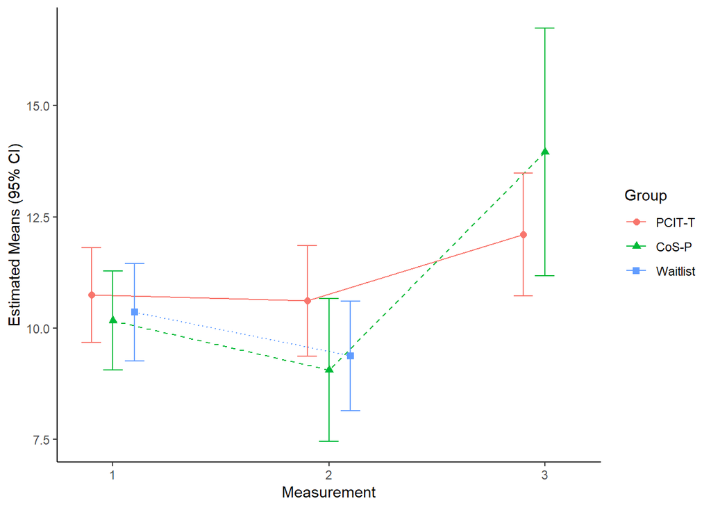

#### Hypothesis 1

We hypothesize that from baseline (‘T1’) to post-treatment/waitlist (‘T2’) there will be a gradient effect, whereby parent-child dyads who receive PCIT-T will show the greatest gains and parent-child dyads who receive no treatment will show the least gains. For the outcome, then, the null hypothesis is:

$H_0: \text {mean change}(\text{PCIT-T}) = \text {mean change}(\text{CoS-P}) = \text {mean change}(\text{Waitlist})$ $H_A: \text {mean change}(\text{PCIT-T}) > \text {mean change}(\text{CoS-P}) > \text {mean change}(\text{Waitlist})$

This is a joint hypothesis test.

First, confirming that the ordering of the means is as hypothesized:

```
## group = 1:
##  contrast estimate    SE    df t.ratio p.value
##  1 - 2       0.131 0.787  91.7   0.167  0.9848
##  1 - 3      -1.360 0.856 103.8  -1.588  0.2552
##  2 - 3      -1.492 0.907  91.7  -1.644  0.2325
##
## group = 2:
##  contrast estimate    SE    df t.ratio p.value
##  1 - 2       1.114 0.943 116.1   1.181  0.4668
##  1 - 3      -3.788 1.473 143.4  -2.571  0.0298
##  2 - 3      -4.902 1.590 130.9  -3.083  0.0070
##
## group = 3:
##  contrast estimate    SE    df t.ratio p.value
##  1 - 2       0.985 0.792  90.5   1.244  0.4306
##  1 - 3      nonEst    NA    NA      NA      NA
##  2 - 3      nonEst    NA    NA      NA      NA
##
## Results are averaged over the levels of: asdcase
## Degrees-of-freedom method: kenward-roger
## P value adjustment: tukey method for comparing a family of 3 estimates
```

```
##   (Intercept) asdcase1 group2 group3 time2 time3 group2:time2 group3:time2
## 1           0        0      0      0     0     0           -1            0
## 2           0        0      0      0     0     1            0            1
##   group2:time3
## 1            0
## 2            0
```

```
##
##   General Linear Hypotheses
##
## Linear Hypotheses:
##        Estimate
## 1 == 0   0.9825
## 2 == 0   0.5069
##
## Global Test:
##        F DF1 DF2 Pr(>F)
## 1 0.5244   2 146  0.593
```

pvalue>0.05. We have no evidence that there is a difference in the change over from Baseline to Post amongst the groups, such that PCITT showed the largest change, then COSP then Waitlist.

#### Hypothesis 2

There will be a gradient of size of change from T2 to T3 such that the change in the PCIT-T group > the change in the CoS-P group. This isn’t really a gradient; it’s just 1 hypothesis.

First, the change in PCITT and COSP from time 2 to time 3:

```
## group = 1:
##  contrast estimate    SE    df t.ratio p.value
##  1 - 2       0.131 0.787  91.7   0.167  0.9848
##  1 - 3      -1.360 0.856 103.8  -1.588  0.2552
##  2 - 3      -1.492 0.907  91.7  -1.644  0.2325
##
## group = 2:
##  contrast estimate    SE    df t.ratio p.value
##  1 - 2       1.114 0.943 116.1   1.181  0.4668
##  1 - 3      -3.788 1.473 143.4  -2.571  0.0298
##  2 - 3      -4.902 1.590 130.9  -3.083  0.0070
##
## group = 3:
##  contrast estimate    SE    df t.ratio p.value
##  1 - 2       0.985 0.792  90.5   1.244  0.4306
##  1 - 3      nonEst    NA    NA      NA      NA
##  2 - 3      nonEst    NA    NA      NA      NA
##
## Results are averaged over the levels of: asdcase
## Degrees-of-freedom method: kenward-roger
## P value adjustment: tukey method for comparing a family of 3 estimates
```

```
##
##   Simultaneous Tests for General Linear Hypotheses
##
## Fit: lmer(formula = outcome ~ asdcase + group * time + (1 | id), data = dat)
##
## Linear Hypotheses:
##        Estimate Std. Error z value Pr(>|z|)
## 1 == 0    3.410      1.815   1.879   0.0603 .
## ---
## Signif. codes:  0 '***' 0.001 '**' 0.01 '*' 0.05 '.' 0.1 ' ' 1
## (Adjusted p values reported -- single-step method)
```

p>0.05.

#### Residuals

Assumptions of the model are met.

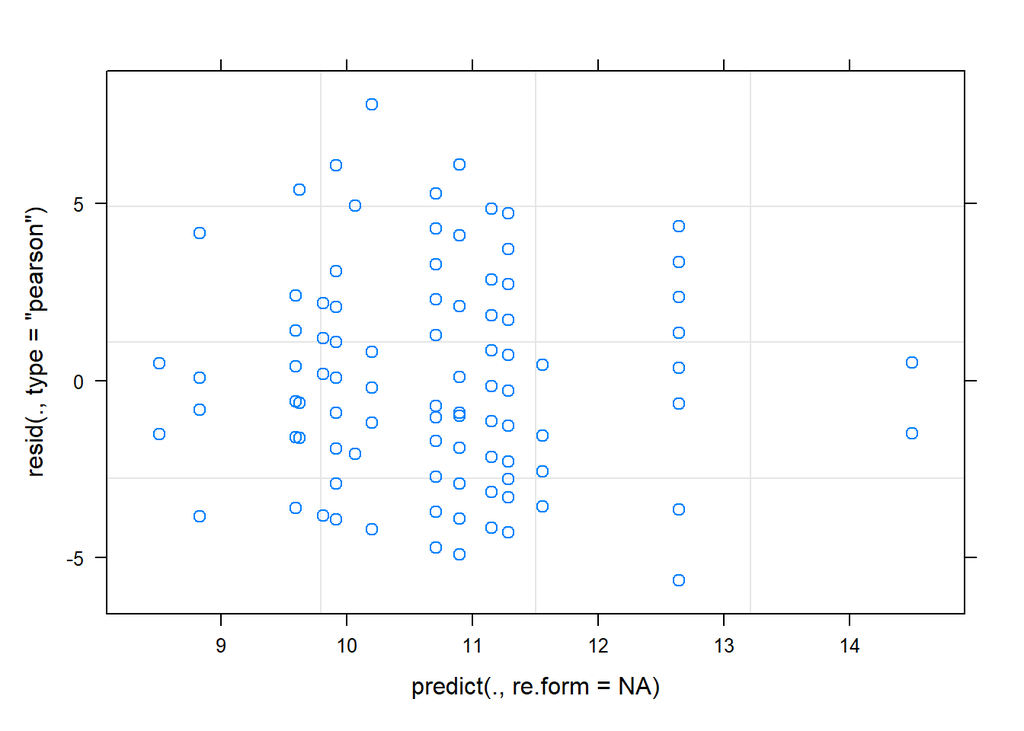

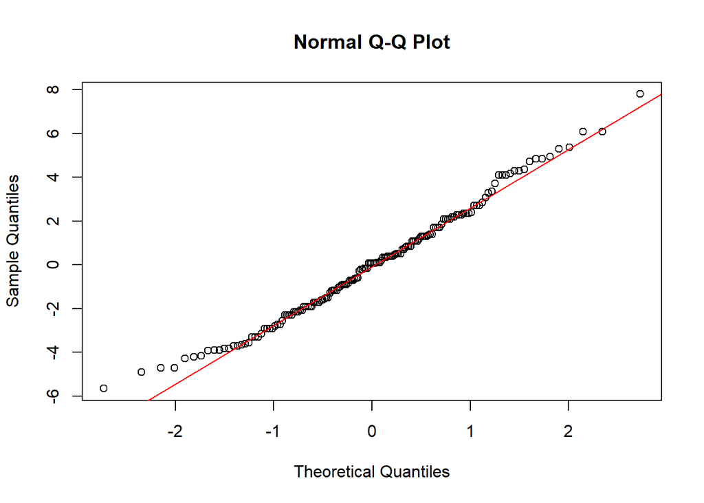

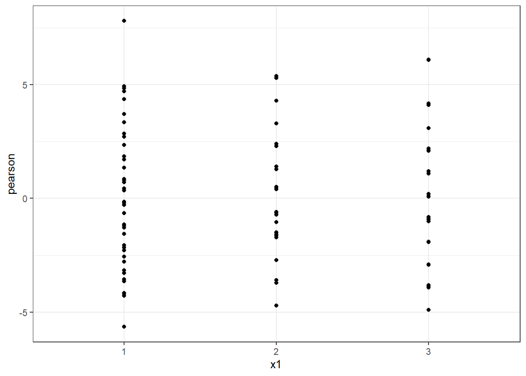

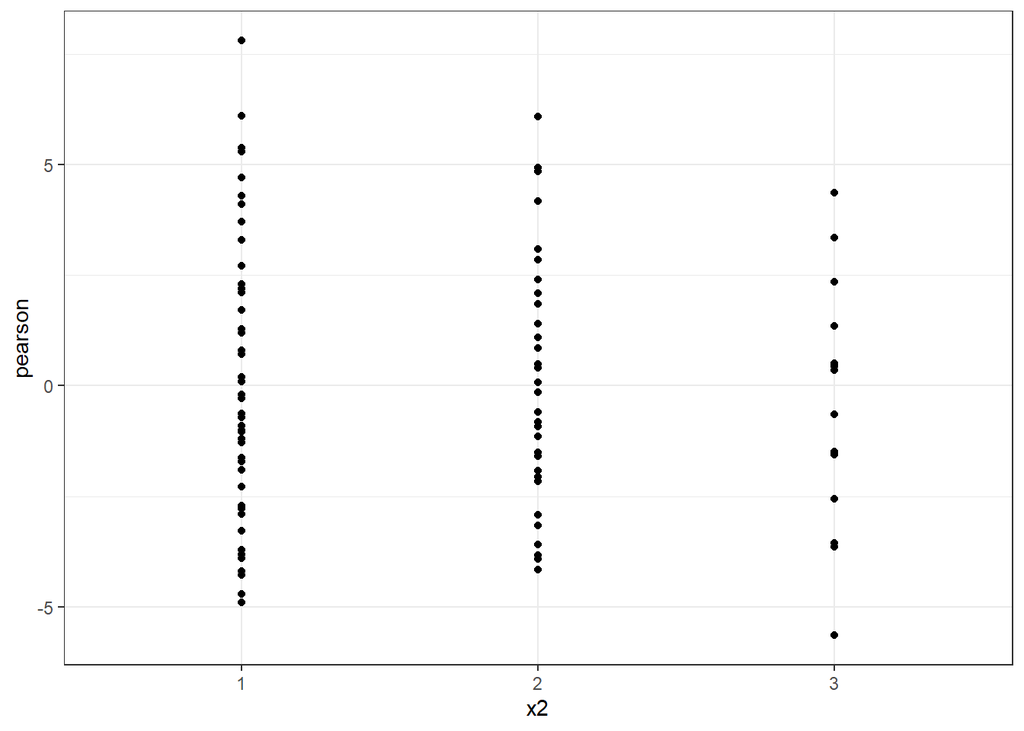

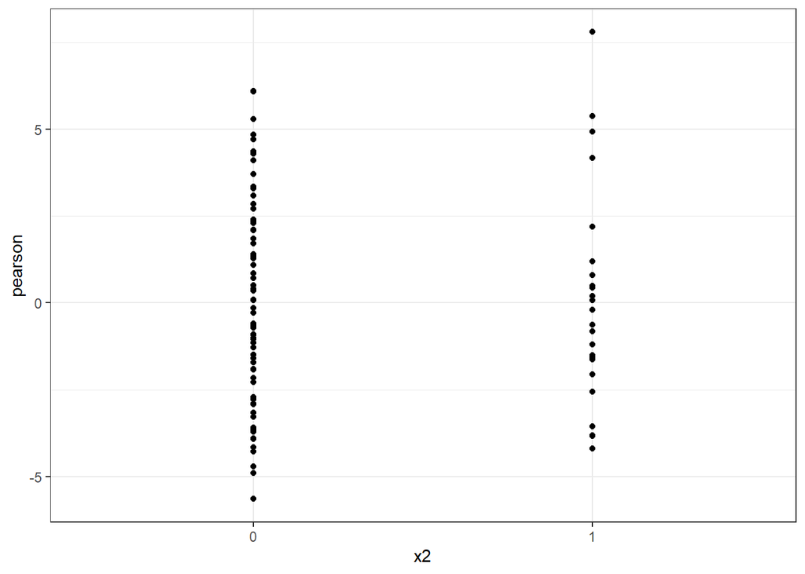

```r
rm(list = ls())
```